# Analyze the bike trips dataset 🚴

The *Bikes trips* dataset comes from a bike station service. It is a collection of information on around 183k trips. Each file has 16 columns includes information on aspects such as start time and trip end_time, user type, member_birth year, and member gender.

> Analysing this data helps in knowing more about the customers and find out about the relationship between the variables. Which lead to offer proper services to the customers.

## *Outline of analysis*

> - Explore the data and ask research questions that could be answered using the data.
> - Performed necessary assesing and cleaning steps to deal with data problems and prepare the dataset for analysis using **pandas**.
> - Created visualizations using *matplotlib and seaborn* and made inferences to answer research questions.

### We will analyze the bikes trips data in order to answer these questions:

- What are the most common days to use a bike?
- What are the most common hours to use a bike?
- What are the common ages and genders of bike users?
- What are the common genders of subscribers users?
- What are the subscribers' Most popular Stations?

### Import Libraries

```python
# import the needed libraries
import pandas as pd
import matplotlib.pyplot as plt
import seaborn as sns
```

### STEP 1: Load Data

```python
# read the csv file, and print the first ten rows

bike_trips = pd.read_csv('bike_trips.csv')
bike_trips.head(10)
```

|  | duration_sec | start_time | end_time | start_station_id | start_station_name | start_station_latitude | start_station_longitude | end_station_id | end_station_name | end_station_latitude | end_station_longitude | bike_id | user_type | member_birth_year | member_gender | bike_share_for_all_trip |
| --- | --- | --- | --- | --- | --- | --- | --- | --- | --- | --- | --- | --- | --- | --- | --- | --- |
| 0 | 52185 | 2019-02-28 17:32:10.1450 | 2019-03-01 08:01:55.9750 | 21.0 | Montgomery St BART Station (Market St at 2nd St) | 37.789625 | -122.400811 | 13.0 | Commercial St at Montgomery St | 37.794231 | -122.402923 | 4902 | Customer | 1984.0 | Male | No |
| 1 | 42521 | 2019-02-28 18:53:21.7890 | 2019-03-01 06:42:03.0560 | 23.0 | The Embarcadero at Steuart St | 37.791464 | -122.391034 | 81.0 | Berry St at 4th St | 37.775880 | -122.393170 | 2535 | Customer | NaN | NaN | No |
| 2 | 61854 | 2019-02-28 12:13:13.2180 | 2019-03-01 05:24:08.1460 | 86.0 | Market St at Dolores St | 37.769305 | -122.426826 | 3.0 | Powell St BART Station (Market St at 4th St) | 37.786375 | -122.404904 | 5905 | Customer | 1972.0 | Male | No |
| 3 | 36490 | 2019-02-28 17:54:26.0100 | 2019-03-01 04:02:36.8420 | 375.0 | Grove St at Masonic Ave | 37.774836 | -122.446546 | 70.0 | Central Ave at Fell St | 37.773311 | -122.444293 | 6638 | Subscriber | 1989.0 | Other | No |
| 4 | 1585 | 2019-02-28 23:54:18.5490 | 2019-03-01 00:20:44.0740 | 7.0 | Frank H Ogawa Plaza | 37.804562 | -122.271738 | 222.0 | 10th Ave at E 15th St | 37.792714 | -122.248780 | 4898 | Subscriber | 1974.0 | Male | Yes |
| 5 | 1793 | 2019-02-28 23:49:58.6320 | 2019-03-01 00:19:51.7600 | 93.0 | 4th St at Mission Bay Blvd S | 37.770407 | -122.391198 | 323.0 | Broadway at Kearny | 37.798014 | -122.405950 | 5200 | Subscriber | 1959.0 | Male | No |
| 6 | 1147 | 2019-02-28 23:55:35.1040 | 2019-03-01 00:14:42.5880 | 300.0 | Palm St at Willow St | 37.317298 | -121.884995 | 312.0 | San Jose Diridon Station | 37.329732 | -121.901782 | 3803 | Subscriber | 1983.0 | Female | No |
| 7 | 1615 | 2019-02-28 23:41:06.7660 | 2019-03-01 00:08:02.7560 | 10.0 | Washington St at Kearny St | 37.795393 | -122.404770 | 127.0 | Valencia St at 21st St | 37.756708 | -122.421025 | 6329 | Subscriber | 1989.0 | Male | No |
| 8 | 1570 | 2019-02-28 23:41:48.7900 | 2019-03-01 00:07:59.7150 | 10.0 | Washington St at Kearny St | 37.795393 | -122.404770 | 127.0 | Valencia St at 21st St | 37.756708 | -122.421025 | 6548 | Subscriber | 1988.0 | Other | No |
| 9 | 1049 | 2019-02-28 23:49:47.6990 | 2019-03-01 00:07:17.0250 | 19.0 | Post St at Kearny St | 37.788975 | -122.403452 | 121.0 | Mission Playground | 37.759210 | -122.421339 | 6488 | Subscriber | 1992.0 | Male | No |

```python
# len(bike_trips.start_station_name.unique())
bike_trips.member_gender.value_counts()
```

```
Male      130651
Female     40844
Other       3652
Name: member_gender, dtype: int64
```

```python
bike_trips.head(2)
```

|  | duration_sec | start_time | end_time | start_station_id | start_station_name | start_station_latitude | start_station_longitude | end_station_id | end_station_name | end_station_latitude | end_station_longitude | bike_id | user_type | member_birth_year | member_gender | bike_share_for_all_trip |
| --- | --- | --- | --- | --- | --- | --- | --- | --- | --- | --- | --- | --- | --- | --- | --- | --- |
| 0 | 52185 | 2019-02-28 17:32:10.1450 | 2019-03-01 08:01:55.9750 | 21.0 | Montgomery St BART Station (Market St at 2nd St) | 37.789625 | -122.400811 | 13.0 | Commercial St at Montgomery St | 37.794231 | -122.402923 | 4902 | Customer | 1984.0 | Male | No |
| 1 | 42521 | 2019-02-28 18:53:21.7890 | 2019-03-01 06:42:03.0560 | 23.0 | The Embarcadero at Steuart St | 37.791464 | -122.391034 | 81.0 | Berry St at 4th St | 37.775880 | -122.393170 | 2535 | Customer | NaN | NaN | No |

### STEP 2: Exploring Data

```python
# how many rows and columns are in the data
bike_trips.shape
```

```
(183412, 16)
```

```python
# what columns are in the data
bike_trips.columns
```

```
Index(['duration_sec', 'start_time', 'end_time', 'start_station_id',
       'start_station_name', 'start_station_latitude',
       'start_station_longitude', 'end_station_id', 'end_station_name',
       'end_station_latitude', 'end_station_longitude', 'bike_id', 'user_type',
       'member_birth_year', 'member_gender', 'bike_share_for_all_trip'],
      dtype='object')
```

```python
# a glimpse of columns datatype and  if there are missing values
bike_trips.info()
```

```
<class 'pandas.core.frame.DataFrame'>
RangeIndex: 183412 entries, 0 to 183411
Data columns (total 16 columns):
 #   Column                   Non-Null Count   Dtype
---  ------                   --------------   -----
 0   duration_sec             183412 non-null  int64
 1   start_time               183412 non-null  object
 2   end_time                 183412 non-null  object
 3   start_station_id         183215 non-null  float64
 4   start_station_name       183215 non-null  object
 5   start_station_latitude   183412 non-null  float64
 6   start_station_longitude  183412 non-null  float64
 7   end_station_id           183215 non-null  float64
 8   end_station_name         183215 non-null  object
 9   end_station_latitude     183412 non-null  float64
 10  end_station_longitude    183412 non-null  float64
 11  bike_id                  183412 non-null  int64
 12  user_type                183412 non-null  object
 13  member_birth_year        175147 non-null  float64
 14  member_gender            175147 non-null  object
 15  bike_share_for_all_trip  183412 non-null  object
dtypes: float64(7), int64(2), object(7)
memory usage: 22.4+ MB
```

```python
bike_trips.describe()
```

|  | duration_sec | start_station_id | start_station_latitude | start_station_longitude | end_station_id | end_station_latitude | end_station_longitude | bike_id | member_birth_year |
| --- | --- | --- | --- | --- | --- | --- | --- | --- | --- |
| count | 183412.000000 | 183215.000000 | 183412.000000 | 183412.000000 | 183215.000000 | 183412.000000 | 183412.000000 | 183412.000000 | 175147.000000 |
| mean | 726.078435 | 138.590427 | 37.771223 | -122.352664 | 136.249123 | 37.771427 | -122.352250 | 4472.906375 | 1984.806437 |
| std | 1794.389780 | 111.778864 | 0.099581 | 0.117097 | 111.515131 | 0.099490 | 0.116673 | 1664.383394 | 10.116689 |
| min | 61.000000 | 3.000000 | 37.317298 | -122.453704 | 3.000000 | 37.317298 | -122.453704 | 11.000000 | 1878.000000 |
| 25% | 325.000000 | 47.000000 | 37.770083 | -122.412408 | 44.000000 | 37.770407 | -122.411726 | 3777.000000 | 1980.000000 |
| 50% | 514.000000 | 104.000000 | 37.780760 | -122.398285 | 100.000000 | 37.781010 | -122.398279 | 4958.000000 | 1987.000000 |
| 75% | 796.000000 | 239.000000 | 37.797280 | -122.286533 | 235.000000 | 37.797320 | -122.288045 | 5502.000000 | 1992.000000 |
| max | 85444.000000 | 398.000000 | 37.880222 | -121.874119 | 398.000000 | 37.880222 | -121.874119 | 6645.000000 | 2001.000000 |

```python
# check for missing data
bike_trips.isnull().sum()
```

```
duration_sec                  0
start_time                    0
end_time                      0
start_station_id            197
start_station_name          197
start_station_latitude        0
start_station_longitude       0
end_station_id              197
end_station_name            197
end_station_latitude          0
end_station_longitude         0
bike_id                       0
user_type                     0
member_birth_year          8265
member_gender              8265
bike_share_for_all_trip       0
dtype: int64
```

```python
# check for duplicates rowa
bike_trips.duplicated().sum()
```

```
0
```

## Data Assess:

From data exploring that we did above here is our note:

> **NOTE:** the dataset has no duplicated columns

## STEP 3: Clean Data

After exploring the dataset, we are ready to start **Data Cleaning** process:

1. Remove Unwanted columns
2. Fix Structural Errors
   > - Convert Columns Datatype
   > - Extract new Columns
3. Handle Missing Data
   > - Filling Missing Values
   > - Drop Missing Values

### 1. Remove Unwanted Columns

Here we will drop the unwanted columns since we think they have no effect on our analysis

```python
# drop the unwanted Columns (index=1 means we want to drop columns)
bike_trips.drop(['start_station_id', 'start_station_latitude', 'start_station_longitude','end_station_id',
                 'end_station_latitude', 'end_station_longitude', 'end_station_longitude'], axis = 1, inplace = True)
```

Check the number of columns

```python
# checking
bike_trips.shape
```

```
(183412, 10)
```

### 2. Fix Structural Errors

#### Convert Columns Datatype

From the output of *info() function*, we can see that

1. 'start_time' and 'end_time' columns has the Object datatype instead of datetime datatype
2. 'user_type' and 'member_gender'columns from Object datatype instead of Category datatype
- We will convert **'start_time'** and **'end_time'** columns from **Object** to **Datetime**

```python
# convert start and end time column to datetime
bike_trips['start_time'] = pd.to_datetime(bike_trips['start_time'])
bike_trips['end_time'] = pd.to_datetime(bike_trips['end_time'])
```

- Convert **'user_type'** and **'member_gender'** columns from **Object** to **Category**

```python
# convert to category
bike_trips['user_type'] = bike_trips['user_type'].astype('category')
bike_trips['member_gender'] = bike_trips['member_gender'].astype('category')
```

> Check the new changes

```python
# checking
bike_trips['member_gender'].dtypes
```

```
CategoricalDtype(categories=['Female', 'Male', 'Other'], ordered=False)
```

```python
bike_trips.info()
```

```
<class 'pandas.core.frame.DataFrame'>
RangeIndex: 183412 entries, 0 to 183411
Data columns (total 10 columns):
 #   Column                   Non-Null Count   Dtype
---  ------                   --------------   -----
 0   duration_sec             183412 non-null  int64
 1   start_time               183412 non-null  datetime64[ns]
 2   end_time                 183412 non-null  datetime64[ns]
 3   start_station_name       183215 non-null  object
 4   end_station_name         183215 non-null  object
 5   bike_id                  183412 non-null  int64
 6   user_type                183412 non-null  category
 7   member_birth_year        175147 non-null  float64
 8   member_gender            175147 non-null  category
 9   bike_share_for_all_trip  183412 non-null  object
dtypes: category(2), datetime64[ns](2), float64(1), int64(2), object(3)
memory usage: 11.5+ MB
```

#### Extract new Columns

- We can Extract **month**, **day** and **hour** from **start_time** column

```python
# extract month, day and hour from start_time column
bike_trips['start_month']= bike_trips['start_time'].dt.strftime('%B')
bike_trips['start_day']= bike_trips['start_time'].dt.strftime('%A')
bike_trips['start_hour']= bike_trips['start_time'].dt.strftime('%H')
```

```python
# checking
bike_trips.head()
```

|  | duration_sec | start_time | end_time | start_station_name | end_station_name | bike_id | user_type | member_birth_year | member_gender | bike_share_for_all_trip | start_month | start_day | start_hour |
| --- | --- | --- | --- | --- | --- | --- | --- | --- | --- | --- | --- | --- | --- |
| 0 | 52185 | 2019-02-28 17:32:10.145 | 2019-03-01 08:01:55.975 | Montgomery St BART Station (Market St at 2nd St) | Commercial St at Montgomery St | 4902 | Customer | 1984.0 | Male | No | February | Thursday | 17 |
| 1 | 42521 | 2019-02-28 18:53:21.789 | 2019-03-01 06:42:03.056 | The Embarcadero at Steuart St | Berry St at 4th St | 2535 | Customer | NaN | NaN | No | February | Thursday | 18 |
| 2 | 61854 | 2019-02-28 12:13:13.218 | 2019-03-01 05:24:08.146 | Market St at Dolores St | Powell St BART Station (Market St at 4th St) | 5905 | Customer | 1972.0 | Male | No | February | Thursday | 12 |
| 3 | 36490 | 2019-02-28 17:54:26.010 | 2019-03-01 04:02:36.842 | Grove St at Masonic Ave | Central Ave at Fell St | 6638 | Subscriber | 1989.0 | Other | No | February | Thursday | 17 |
| 4 | 1585 | 2019-02-28 23:54:18.549 | 2019-03-01 00:20:44.074 | Frank H Ogawa Plaza | 10th Ave at E 15th St | 4898 | Subscriber | 1974.0 | Male | Yes | February | Thursday | 23 |

- We can calculate **member age** from **member_birth_year**.

```python
# calculate member_age from member_birth_year and save it to a new column called "member_age".
bike_trips['member_age'] = 2022 - bike_trips['member_birth_year']
```

```python
# checking
bike_trips.head()
```

|  | duration_sec | start_time | end_time | start_station_name | end_station_name | bike_id | user_type | member_birth_year | member_gender | bike_share_for_all_trip | start_month | start_day | start_hour | member_age |
| --- | --- | --- | --- | --- | --- | --- | --- | --- | --- | --- | --- | --- | --- | --- |
| 0 | 52185 | 2019-02-28 17:32:10.145 | 2019-03-01 08:01:55.975 | Montgomery St BART Station (Market St at 2nd St) | Commercial St at Montgomery St | 4902 | Customer | 1984.0 | Male | No | February | Thursday | 17 | 38.0 |
| 1 | 42521 | 2019-02-28 18:53:21.789 | 2019-03-01 06:42:03.056 | The Embarcadero at Steuart St | Berry St at 4th St | 2535 | Customer | NaN | NaN | No | February | Thursday | 18 | NaN |
| 2 | 61854 | 2019-02-28 12:13:13.218 | 2019-03-01 05:24:08.146 | Market St at Dolores St | Powell St BART Station (Market St at 4th St) | 5905 | Customer | 1972.0 | Male | No | February | Thursday | 12 | 50.0 |
| 3 | 36490 | 2019-02-28 17:54:26.010 | 2019-03-01 04:02:36.842 | Grove St at Masonic Ave | Central Ave at Fell St | 6638 | Subscriber | 1989.0 | Other | No | February | Thursday | 17 | 33.0 |
| 4 | 1585 | 2019-02-28 23:54:18.549 | 2019-03-01 00:20:44.074 | Frank H Ogawa Plaza | 10th Ave at E 15th St | 4898 | Subscriber | 1974.0 | Male | Yes | February | Thursday | 23 | 48.0 |

> Check the new changes

```python
# checking
bike_trips['member_age']
```

```
0         38.0
1          NaN
2         50.0
3         33.0
4         48.0
          ...
183407    26.0
183408    38.0
183409    32.0
183410    34.0
183411    33.0
Name: member_age, Length: 183412, dtype: float64
```

- After we calculated member age we don't need **'member_birth_year'** anymore so we will delete it

```python
# Delete member_birth_year column.
bike_trips.drop(['member_birth_year'], axis = 1, inplace = True)
```

- Note that the **member age** column has a float datatype, but we cannot fix it now since there are some null values.

> **We should handle with null values first**

### 3. Handle Missing Data

> **First**, let's see which columns contain null values

```python
bike_trips.isnull().sum()
```

```
duration_sec                  0
start_time                    0
end_time                      0
start_station_name          197
end_station_name            197
bike_id                       0
user_type                     0
member_gender              8265
bike_share_for_all_trip       0
start_month                   0
start_day                     0
start_hour                    0
member_age                 8265
dtype: int64
```

- As we can see, there are 4 columns with null values:
1. start_station_name
2. end_station_name
3. member_gender
4. member_age

The handling of these missing values varies according to their data type.

- We will first start by dealing with the **member age** column

> We can fill in the missing values in the **member age** column with the mean age of all members

```python
# fill the missing values with the mean of ages ( mean of column values)
bike_trips['member_age'] = bike_trips['member_age'].fillna(bike_trips['member_age'].mean())
```

> Check the new changes in "**member_age**" column

```python
# checking
bike_trips.isnull().sum()
```

```
duration_sec                  0
start_time                    0
end_time                      0
start_station_name          197
end_station_name            197
bike_id                       0
user_type                     0
member_gender              8265
bike_share_for_all_trip       0
start_month                   0
start_day                     0
start_hour                    0
member_age                    0
dtype: int64
```

> Now after we handel null values in the 'member age column':
> - We can convert **'member_age'** column from **Float64** to **Int**

```python
# convert float to integer data type( ages can't be a float)
bike_trips['member_age'] = bike_trips['member_age'].astype(int)
```

We have solved the problem with null values in the **member age** column, but we still have 3 columns with null values.

> *since their values will not affect the analysis that much we can just drop them*

```python
# drop all missing values
bike_trips.dropna(axis = 0, inplace = True)
```

> Check if there is any null values now

```python
# checking
bike_trips.isnull().sum()
```

```
duration_sec               0
start_time                 0
end_time                   0
start_station_name         0
end_station_name           0
bike_id                    0
user_type                  0
member_gender              0
bike_share_for_all_trip    0
start_month                0
start_day                  0
start_hour                 0
member_age                 0
dtype: int64
```

### STEP 4: Exploratory Data Analysis & Visualizations

### Question 1 : What are the most common days to use a bike?

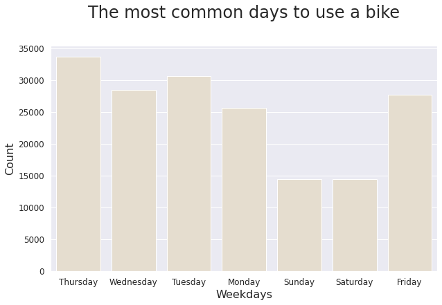

```python
plt.figure(figsize=(10,6));


vis_1 = sns.countplot(data = bike_trips, x = 'start_day', color = 'moccasin', saturation=0.3)
vis_1.set_xlabel("Weekdays",fontsize=16)
vis_1.set_ylabel("Count",fontsize=16)
vis_1.tick_params(labelsize=12)
plt.title('The most common days to use a bike',fontsize=24, pad = 40)

plt.show();
```

> From the above bar chart, we can notice that *Thursday* is the most popular to use bikes followed by *Tuesday*. while *Sunday and Saturday* are the least popular days.

### Question 2 : What are the most common hours to use a bike?

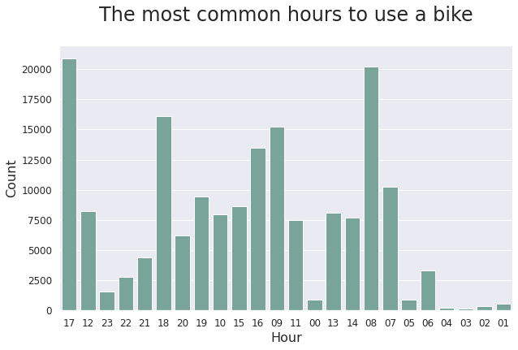

```python
plt.figure(figsize=(10,6));

vis_2 = sns.countplot(data = bike_trips, x = 'start_hour', color='#69b3a2', saturation=0.6);
vis_2.set_xlabel("Hour",fontsize=16)
vis_2.set_ylabel("Count",fontsize=16)
vis_2.tick_params(labelsize=12)
plt.title('The most common hours to use a bike',fontsize=24, pad = 30)

plt.show();
```

> The first five hours (12 a.m - 4 a.m) of the day got the least count of bike usage. But 5 p.m and 8 a.m are the most common hours to use bikes.

### Question 3 : What are the common ages and genders of bike users?

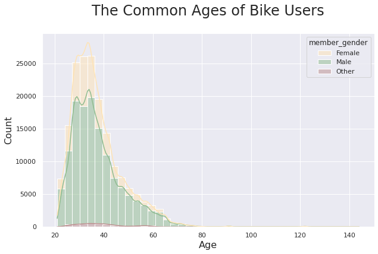

```python
plt.figure(figsize=(10,6));
# plt.hist(data = bike_trips, x = 'member_age', color = '#ded6be');
colors= ['moccasin','darkseagreen',  'rosybrown']
sns.histplot(data=bike_trips, x="member_age", hue="member_gender", multiple="stack", palette=colors , bins=40,  kde=True)


plt.title('The Common Ages of Bike Users',fontsize=24, pad = 30)
plt.xlabel('Age',fontsize=16);
plt.ylabel('Count',fontsize=16);
```

> The common ages of bike users range from 20 to 45 years old.

### Question 4 : What are the common genders of subscribers users?

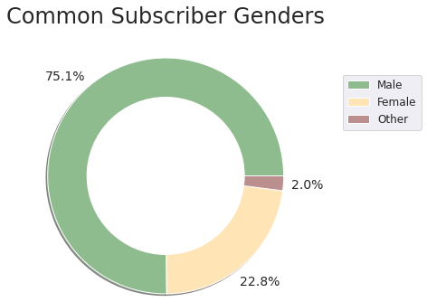

```python
subscriber_pop_chart = bike_trips.query("user_type == 'Subscriber' ")['member_gender'].value_counts()
labels_list=['Male','Female','Other']

colors=['darkseagreen', 'moccasin', 'rosybrown', 'lightyellow']


plt.pie(subscriber_pop_chart,colors= colors ,shadow=True,pctdistance=1.2,
        autopct='%1.1f%%',textprops={'fontsize': 14}, radius =1.5)

# to  change pie chart to donut chart
centre_circle = plt.Circle((0,0),1.0,fc='white')
fig = plt.gcf()
fig.gca().add_artist(centre_circle)


plt.legend(labels=labels_list, loc='upper center',
           bbox_to_anchor=(1.6, 1.04), ncol=1, fontsize=12)
plt.title('Common Subscriber Genders',fontsize=24, pad=60);
```

> *Male users* are the most common bike' subscribers.

### Question 5 : What are the subscribers' Most popular Stations?

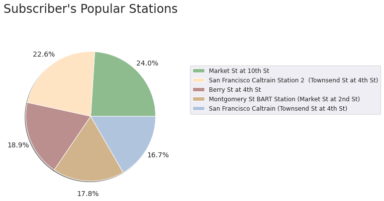

```python
common_station= bike_trips.query("user_type == 'Subscriber' ").start_station_name.value_counts()

df_val_counts = pd.DataFrame(common_station[:5]) # take only the most 5 popular station
df_val_counts = df_val_counts.reset_index()
df_val_counts.columns = ['station_name', 'counts'] # change column names
labels_list = list(df_val_counts['station_name']) # to get the station name list


colors=['darkseagreen', 'bisque', 'rosybrown', 'tan', 'lightsteelblue']

plt.pie(common_station[:5],shadow=True,pctdistance=1.2,
        autopct='%1.1f%%',textprops={'fontsize': 14}, radius =1.5, colors=colors)



plt.legend(labels=labels_list, loc='upper center',
           bbox_to_anchor=(2.3, 1.0), ncol=1, fontsize=12)
plt.title("Subscriber's Popular Stations",fontsize=24, pad=100);
```

> *Market St at 10th St* and *San Francisco Caltrain Station 2 (Townsend St at 4th St)* Stations are the Most popular Stations to subscribers.

### Limitations

> *So I had to clean the dataset before start answering my research questions.*

### Conclusions

> 1. Thursday is the most popular to use bikes.
> 2. Sunday and Saturday are the least popular days.
> 3. 5 p.m and 8 a.m are the most common hours to use bikes.
> 4. The common ages of bike users range from 20 to 45 years old.
> 5. Most of the subscribers are Male users.
> 6. *Market St at 10th St* is the Most popular Station to subscribers.